# Data Anaylsis on COVID-19

STAT 184 Final Project

Weslee Hwang and Gary Andrew Modzelewski

## Coronavirus

###### Front Matter

```r
# clean up workspace environment
rm(list = ls())

# all packages used for the assignment
library(mosaic)
library(tidyverse)
library(DataComputing)
library(lubridate)
library(party)
```

###### Data Imports

```r
# WHO Corona dataset
coronavirus <- read.csv("total_cases.csv")
confirmed <- read.csv("covid19confirmed.csv")

#data sets used provided by ECDC and OurWorld
ecdc <- read.csv("https://opendata.ecdc.europa.eu/covid19/casedistribution/csv", na.strings="",fileEncoding="UTF-8-BOM")

covid19 <- read.csv("total_cases_apr25.csv")
```

## Introduction

COVID-19, more commonly know as the coronavirus, has taken the world by a storm. A fast spreading disease with similar ways of penetrating a human’s immune system as the flu, it has been rapidly infecting people at a high rate. With some of the world’s biggest nations subsequently be left in the hands of a random variable businesses, facilities, and a way of life has been threatened.

The purpose of this document is take a deeper look at the effects and spread of the COVID-19. We want to run an analysis on the impact it on specific countries, projecting the spread with accounts to location, population size, and preliminary precautions.

## Focus

```
Mapping API still under development and may change in future releases.
6 items were not translated
```

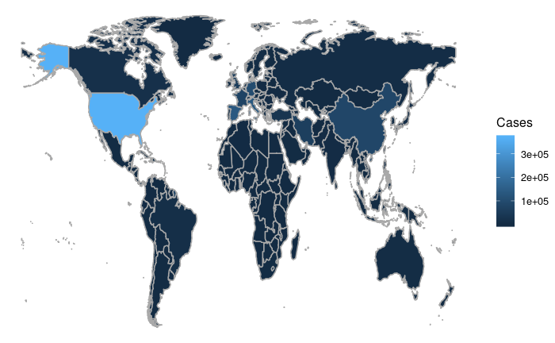

```r
## Transposed dataframe setting dates as variables
coronaMap <- setNames(data.frame(t(coronavirus[,-1])), coronavirus[,1])

## Renamed variable for countries
coronaMap <- coronaMap %>%
  rownames_to_column(var = "country")

## Removed world from countries list
coronaMap = coronaMap[-1,]

## Used regex to remove periods inbetween country names
like <- "\\."
coronaMap <- coronaMap %>%
  mutate(country = gsub(pattern = like, replacement = " ", country))

## Visual of data on world map
coronaMap <- coronaMap %>%
  rename(Cases = `2020-04-07`)

coronaMap %>%
  WorldMap(key = country, fill = Cases)
```

```r
as.data.frame(coronaMap[,c(1,100)]) %>%
  filter(Cases > 10000) %>%
  arrange(desc(Cases))
```

| country | Cases |
| --- | --- |
| United States | 368196 |
| Spain | 135032 |
| Italy | 132547 |
| Germany | 99225 |
| China | 82698 |
| France | 74390 |
| Iran | 60500 |
| United Kingdom | 51608 |
| Turkey | 30217 |
| Switzerland | 21574 |

[output cut: 7 more lines]

## Data Source

##### Where did you find them?

We found our data looking for .csv files of cases on the coronavirus.

##### Who collected/maintains them?

The data is collected by the European Centre for Disease Prevention and Control (ECDC) but maintained in csv format by Our World Data.

##### When & Why were they originally collected?

Every day from 6am to 10am CET data is published by the ECDC and formatted for .csv around 1pm CET by Our World Data. The data is originally collected to keep a track of the situation regaurding the coronavirus.

##### What does a case represent in each data source, and how many total cases are availiable?

```r
coronavirus
```

| date | World | Afghanistan | Albania | Algeria | Andorra | Angola | Anguilla | Antigua.and.Barbuda | Argentina | Armenia | Aruba | Australia | Austria | Azerbaijan | Bahamas | Bahrain | Bangladesh | Barbados | Belarus | Belgium | Belize | Benin | Bermuda | Bhutan | Bolivia | Bonaire.Sint.Eustatius.and.Saba | Bosnia.and.Herzegovina | Botswana | Brazil | … |
| --- | --- | --- | --- | --- | --- | --- | --- | --- | --- | --- | --- | --- | --- | --- | --- | --- | --- | --- | --- | --- | --- | --- | --- | --- | --- | --- | --- | --- | --- | --- |
| 2019-12-31 | 27 | 0 | NA | 0 | NA | NA | NA | NA | NA | 0 | NA | 0 | 0 | 0 | NA | 0 | NA | NA | 0 | 0 | NA | NA | NA | NA | NA | NA | NA | NA | 0 | … |
| 2020-01-01 | 27 | 0 | NA | 0 | NA | NA | NA | NA | NA | 0 | NA | 0 | 0 | 0 | NA | 0 | NA | NA | 0 | 0 | NA | NA | NA | NA | NA | NA | NA | NA | 0 | … |
| 2020-01-02 | 27 | 0 | NA | 0 | NA | NA | NA | NA | NA | 0 | NA | 0 | 0 | 0 | NA | 0 | NA | NA | 0 | 0 | NA | NA | NA | NA | NA | NA | NA | NA | 0 | … |
| 2020-01-03 | 44 | 0 | NA | 0 | NA | NA | NA | NA | NA | 0 | NA | 0 | 0 | 0 | NA | 0 | NA | NA | 0 | 0 | NA | NA | NA | NA | NA | NA | NA | NA | 0 | … |
| 2020-01-04 | 44 | 0 | NA | 0 | NA | NA | NA | NA | NA | 0 | NA | 0 | 0 | 0 | NA | 0 | NA | NA | 0 | 0 | NA | NA | NA | NA | NA | NA | NA | NA | 0 | … |
| 2020-01-05 | 59 | 0 | NA | 0 | NA | NA | NA | NA | NA | 0 | NA | 0 | 0 | 0 | NA | 0 | NA | NA | 0 | 0 | NA | NA | NA | NA | NA | NA | NA | NA | 0 | … |
| 2020-01-06 | 59 | 0 | NA | 0 | NA | NA | NA | NA | NA | 0 | NA | 0 | 0 | 0 | NA | 0 | NA | NA | 0 | 0 | NA | NA | NA | NA | NA | NA | NA | NA | 0 | … |
| 2020-01-07 | 59 | 0 | NA | 0 | NA | NA | NA | NA | NA | 0 | NA | 0 | 0 | 0 | NA | 0 | NA | NA | 0 | 0 | NA | NA | NA | NA | NA | NA | NA | NA | 0 | … |
| 2020-01-08 | 59 | 0 | NA | 0 | NA | NA | NA | NA | NA | 0 | NA | 0 | 0 | 0 | NA | 0 | NA | NA | 0 | 0 | NA | NA | NA | NA | NA | NA | NA | NA | 0 | … |
| 2020-01-09 | 59 | 0 | NA | 0 | NA | NA | NA | NA | NA | 0 | NA | 0 | 0 | 0 | NA | 0 | NA | NA | 0 | 0 | NA | NA | NA | NA | NA | NA | NA | NA | 0 | … |

[output cut: 89 more lines]

##### What are some variables that you plan to use?

Variables we plan on using is the date and countries(perferably countries with the high cases like United States, China, Italy, Spain)

## Explore intuition related to the research question

#### World

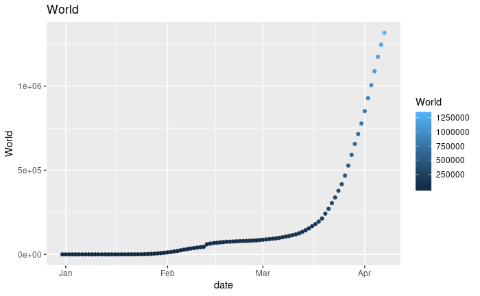

```r
## Format Year, Month, and Date to R standards
coronavirus <- coronavirus %>%
  mutate(date = ymd(date))

coronavirus %>%
  ggplot(aes(x = date, y = World)) +
  geom_point(aes(color = World)) +
  ggtitle("World")
```

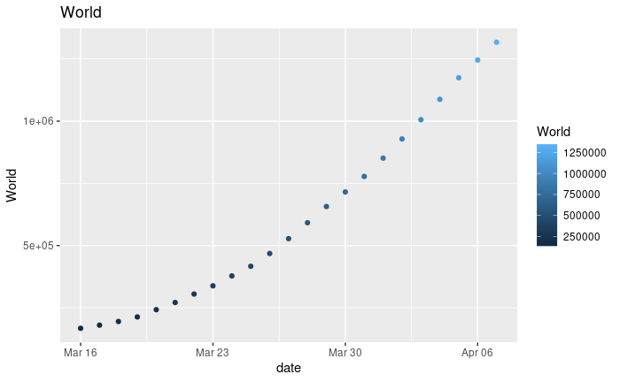

```r
coronavirus %>%
  filter(date > as.Date("2020-03-15")) %>%
  ggplot(aes(x = date, y = World)) +
  geom_point(aes(color = World)) +
  ggtitle("World")
```

Running an anaylsis on the total cases of the World, we notice that the amount of cases are steady from mid March to the beginning of January. It rapid increase can be seen from March 16 to April 06, with cases increasing from 167,418 to 1,316,988 cases.

```r
days = 15
end = 1316988
begin = 167418
if(end > begin){
difference = end-begin
(difference/begin) * 100
}
```

```
[1] 686.6466
```

From this period between March 16 to April 06, we had an increase amoung of cases of 686.65 percent.

#### China

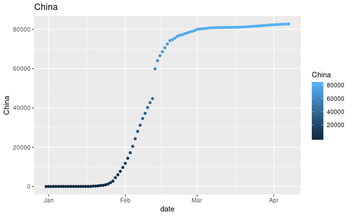

```r
coronavirus %>%
  ggplot(aes(x = date, y = China)) +
  geom_point(aes(color = China)) +
  ggtitle("China")
```

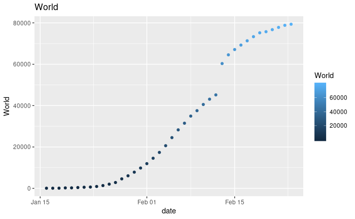

```r
coronavirus %>%
  filter(date < as.Date("2020-02-25"), date > as.Date("2020-01-15")) %>%
  ggplot(aes(x = date, y = World)) +
  geom_point(aes(color = World)) +
  ggtitle("World")
```

It is important to look at China when analyzing the COVID-19. The virus intially started in Wuhan, China with patient zero starting the infection with the consumtion of a uncooked bat. Being the origin of the virus China was the first to be impacted by COVID-19. We can analyze an rapid growth between January 25 to Febuary 25. We can also notice that the country is plateauing from Febuary 25 and beyond. Their initial response to the disease put the city of Wuhan under quaritine on Janaury 23 (https://www.express.co.uk/travel/articles/1257717/china-lockdown-how-long-was-china-lockdown-timeframe-wuhan). China having a population of 1.3 billion and the city of Wuhan with 11 million, the difficulty of containing and tending to each person has had Wuhan’s current infrastructure full. Reacting quickly to COVID-19, China started the construction of two medical facilities on January 23 and January 25, operational on Febuary 3 and Febuary 5 respectively. Each medical facility could house 1000 plus patients at once and were close by city districts (https://www.wsj.com/articles/how-china-can-build-a-coronavirus-hospital-in-10-days-11580397751). As the virus takes 2 weeks to confirm a case, we can see some correlation from the constructions of the hospitals and a nation wide quaritine to the plateauing from Febuary 25 and beyond.

[figure not shown]

#### Spain

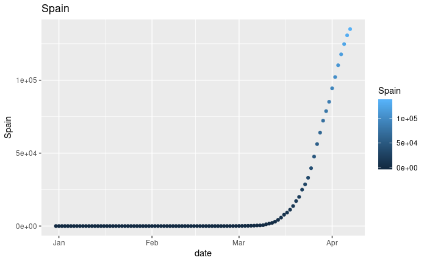

```r
coronavirus %>%
  ggplot(aes(x = date, y = Spain)) +
  geom_point(aes(color = Spain)) +
  ggtitle("Spain")
```

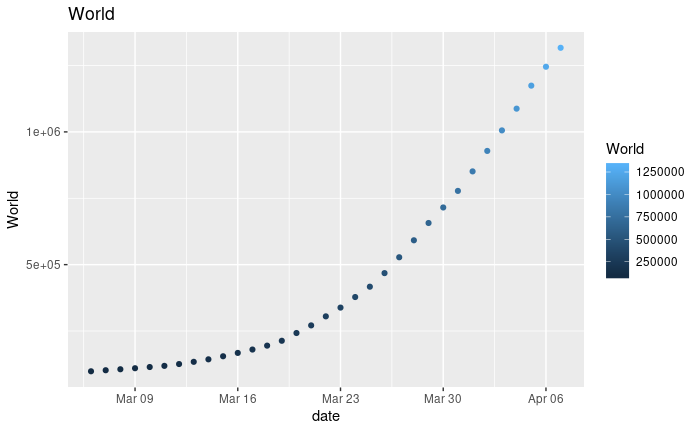

```r
coronavirus %>%
  filter(date > as.Date("2020-03-5")) %>%
  ggplot(aes(x = date, y = World)) +
  geom_point(aes(color = World)) +
  ggtitle("World")
```

Spain currently holds the second place right after the United States. It has had a rapid growth from March til April. This could be accounted for its late reaction to lock down. Spain decided to lock down its country March 14, after the epidemic started to increase its numbers. Their late reaction to the epidemic could account for its increase of cases in the mount of March. (https://www.aljazeera.com/news/2020/04/month-lockdown-spain-children-200421115609252.html)

#### United States

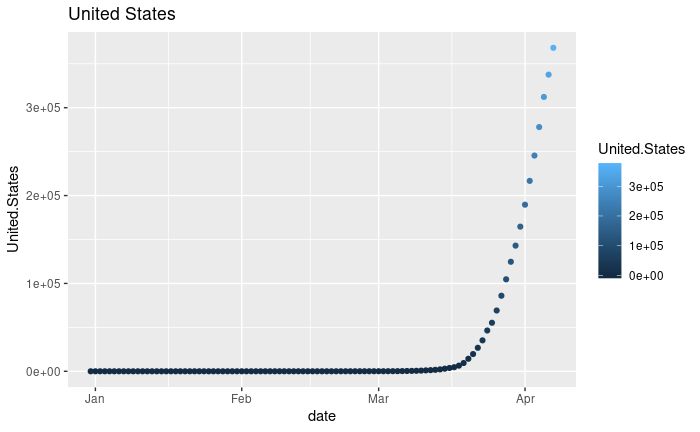

```r
coronavirus %>%
  ggplot(aes(x = date, y = United.States)) +
  geom_point(aes(color = United.States)) +
  ggtitle("United States")
```

United States holds the highest amount of cases currently in the world. United States had a similar reaction compared to Spain. They reacted late to the epidemic, starting quaritine mid March. As each state governs its own lock down date, New York started quaritine March 16. Altough starting its quartine relative to other states, it remains the state with the most cases with nearly 300,000. It can be attributed to New York City with a population of 8 million people 302 mile square. Relatively a less densely populated state like South Dakota has around 2,000 cases.

- **How do COVID-19 cases compare in various countries around the world, along with total global cases?**
- The ECDC data set is provided and maintained by the European Centre for Disease Prevention and Control. The data is used to keep track of the total number of confirmed cases of COVID-19 around the world. Each data set case represents the total number of COVID-19 cases in a given country on a given day. All cases are up-to-date as of April 25, 2020.
- The covid19 data set is provided by Our World in Data and is updated daily. It provides similar data as the ECDC data set, and has been recording data “since the beginning of the pandemic”.

```r
covid19
```

| iso_code | location | date | total_cases | new_cases | total_deaths | new_deaths | total_cases_per_million | new_cases_per_million | total_deaths_per_million | new_deaths_per_million | total_tests | new_tests | total_tests_per_thousand | new_tests_per_thousand | tests_units |
| --- | --- | --- | --- | --- | --- | --- | --- | --- | --- | --- | --- | --- | --- | --- | --- |
| ABW | Aruba | 2020-03-13 | 2 | 2 | 0 | 0 | 18.733 | 18.733 | 0.000 | 0.000 | NA | NA | NA | NA |  |
| ABW | Aruba | 2020-03-20 | 4 | 2 | 0 | 0 | 37.465 | 18.733 | 0.000 | 0.000 | NA | NA | NA | NA |  |
| ABW | Aruba | 2020-03-24 | 12 | 8 | 0 | 0 | 112.395 | 74.930 | 0.000 | 0.000 | NA | NA | NA | NA |  |
| ABW | Aruba | 2020-03-25 | 17 | 5 | 0 | 0 | 159.227 | 46.831 | 0.000 | 0.000 | NA | NA | NA | NA |  |
| ABW | Aruba | 2020-03-26 | 19 | 2 | 0 | 0 | 177.959 | 18.733 | 0.000 | 0.000 | NA | NA | NA | NA |  |
| ABW | Aruba | 2020-03-27 | 28 | 9 | 0 | 0 | 262.256 | 84.296 | 0.000 | 0.000 | NA | NA | NA | NA |  |
| ABW | Aruba | 2020-03-28 | 28 | 0 | 0 | 0 | 262.256 | 0.000 | 0.000 | 0.000 | NA | NA | NA | NA |  |
| ABW | Aruba | 2020-03-29 | 28 | 0 | 0 | 0 | 262.256 | 0.000 | 0.000 | 0.000 | NA | NA | NA | NA |  |
| ABW | Aruba | 2020-03-30 | 50 | 22 | 0 | 0 | 468.314 | 206.058 | 0.000 | 0.000 | NA | NA | NA | NA |  |
| ABW | Aruba | 2020-04-01 | 55 | 5 | 0 | 0 | 515.145 | 46.831 | 0.000 | 0.000 | NA | NA | NA | NA |  |

[output cut: 990 more lines]

- Every country in the world has reported cases of COVID-19. The bar graph below shows the countries with over 15,000 confirmed cases.

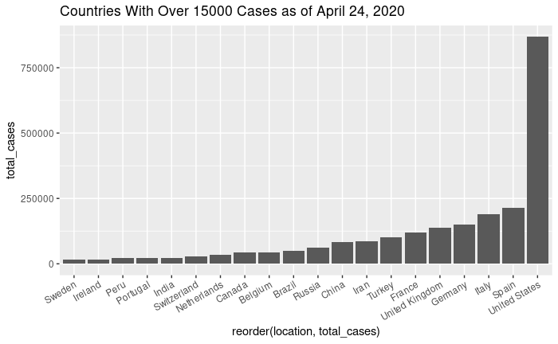

```r
cases <- covid19 %>%
  filter(date == "2020-04-24") %>%
  select(location, total_cases) %>%
  group_by(location, total_cases)

cases %>%
  filter(total_cases > 15000, location != "World") %>%
  ggplot() +
  geom_bar(aes(reorder(location, total_cases), total_cases), stat = 'identity', position = 'dodge') +
  ggtitle("Countries With Over 15000 Cases as of April 24, 2020") +
  theme(axis.text.x = element_text(angle = 30, hjust = 1))
```

- It is obvious that the United States has by far the most confirmed cases of the virus. Although the United States has the most cases, they have also done the most testing. When taking the ratio between confirmed cases and total tests, the United States has the third highest ratio. The United Kingdom has the largest ratio.
- **It should be noted that the ratios are affected by someone being able to be tested. For example in the United Kingdom, many people were tested after going to the hospital with symptoms.**

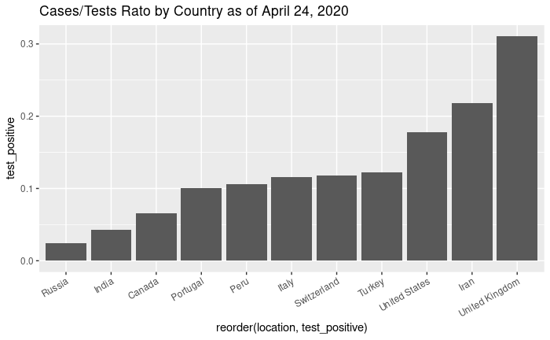

```r
cases <- covid19 %>%
  filter(date == "2020-04-24", total_cases > 15000) %>%
  select(location, total_cases, total_tests)  %>%
  mutate(test_positive = total_cases / total_tests)

validcases <- na.omit(cases)

validcases %>%
  ggplot() +
  geom_bar(aes(reorder(location, test_positive), test_positive), stat = 'identity', position = 'dodge') +
  ggtitle("Cases/Tests Rato by Country as of April 24, 2020") +
  theme(axis.text.x = element_text(angle = 30, hjust = 1))
```

- The next few graphs look at the reported cases and deaths of COVID-19 for the United States, China, and Italy. As expected, the number of deaths increase with the number of cases.
- Italy has a higher death rate than the United States and China because they have a higher median age, as well as being one of the first countries to be afflicted. Italy is one of the main reasons the United States is currently under quarantine, so as to not overwhelm hospitals.

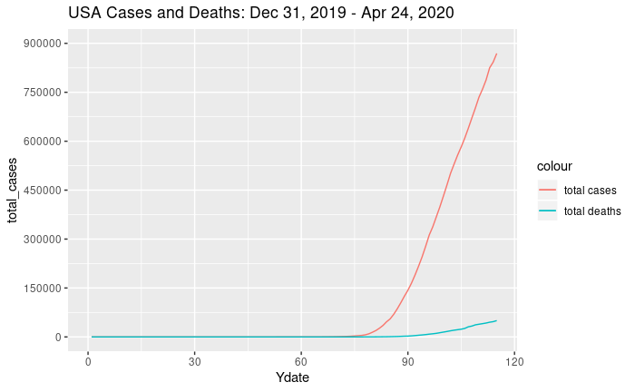

```r
UScases <- covid19 %>%
  filter(location == "United States")

UScases %>%
  mutate(Ydate = lubridate::yday(date)) %>%
  ggplot(aes(x = Ydate)) + geom_line(aes(y = total_cases, color = "total cases")) +
  geom_line(aes(y = total_deaths, color = "total deaths")) +
  ggtitle("USA Cases and Deaths: Dec 31, 2019 - Apr 24, 2020") +
  scale_y_continuous(limits = c(0, 900000), breaks = seq(0, 900000, by = 150000)) +
  xlim(0,115)
```

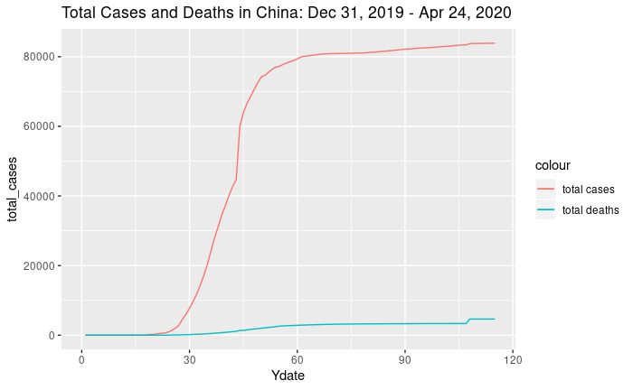

```r
covid19 %>%
  mutate(Ydate = lubridate::yday(date)) %>%
  filter(location == "China") %>%
  ggplot(aes(x = Ydate)) +
  geom_line(aes(y = total_cases, color = "total cases")) +
  geom_line(aes(y = total_deaths, color = "total deaths")) +
  ggtitle("Total Cases and Deaths in China: Dec 31, 2019 - Apr 24, 2020") +
  xlim(0,115)
```

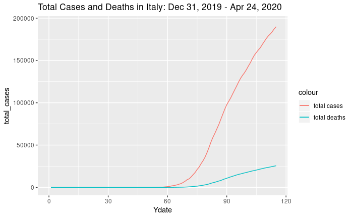

```r
covid19 %>%
  mutate(Ydate = lubridate::yday(date)) %>%
  filter(location == "Italy") %>%
  ggplot(aes(x = Ydate)) +
  geom_line(aes(y = total_cases, color = "total cases")) +
  geom_line(aes(y = total_deaths, color = "total deaths")) +
  ggtitle("Total Cases and Deaths in Italy: Dec 31, 2019 - Apr 24, 2020") +
  xlim(0,115)
```

- The side-by-side comparisions show just how stark the difference in total cases is for the United States, as well as the total deaths for Italy. It has been reported that China was able to flatten the curve as much as they did by implementing strict lockdown measures.

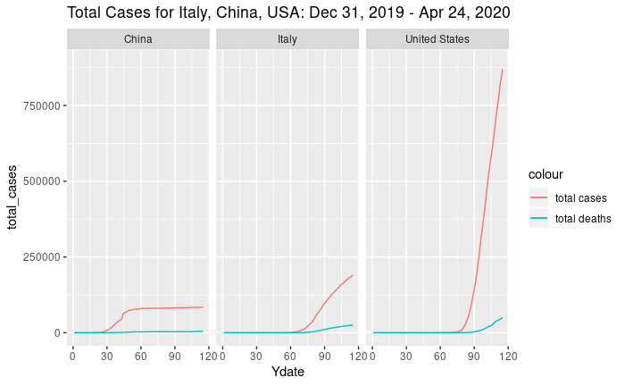

```r
ICA <- c("Italy", "China", "United States")

MediaCases <- covid19 %>% filter(location %in% ICA)

MediaCases %>%
  mutate(Ydate = lubridate::yday(date)) %>%
  ggplot(aes(x = Ydate)) + geom_line(aes(y = total_cases, color = "total cases")) +
  geom_line(aes(y = total_deaths, color = "total deaths")) + facet_wrap(~location) +
  ggtitle("Total Cases for Italy, China, USA: Dec 31, 2019 - Apr 24, 2020") +
  xlim(0,115)
```

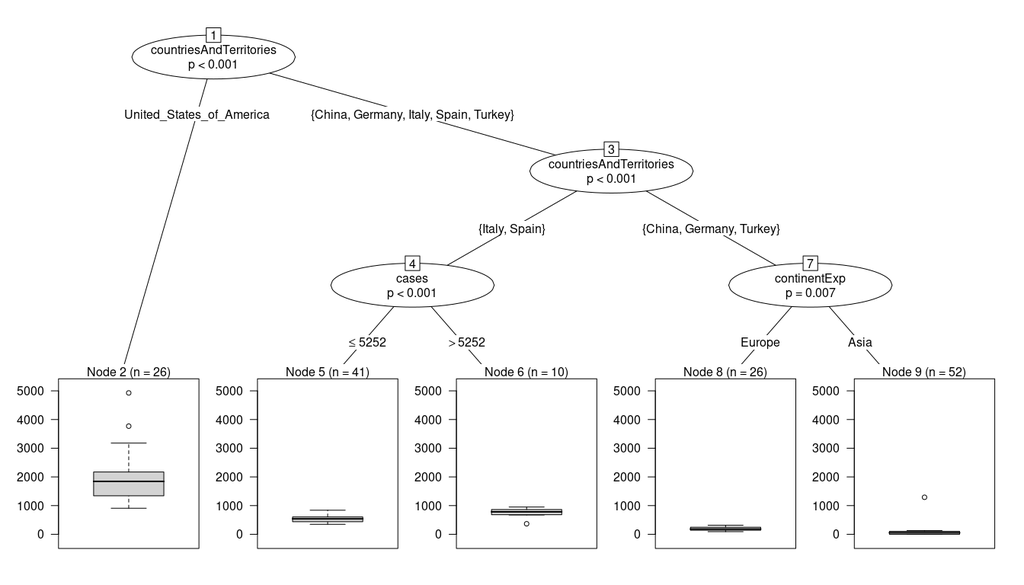

```r
MainCountries <- c("United_States_of_America", "Turkey", "Germany", "Italy", "Spain", "China")

ecdcMain <- ecdc %>%
  filter(countriesAndTerritories %in% MainCountries, month == 4)

MostDeaths <- ecdcMain %>%
  ctree(deaths ~ continentExp+countriesAndTerritories+popData2018+cases, data = .)

plot(MostDeaths)
```